# GLORYS reanalysis bottom temperature

Sarah Gaichas

2026-07-17

## 1 What is GLORYS?

Copernicus products (https://data.marine.copernicus.eu/products) including the Global Oceanic Reanalysis (GLORYS, [1], https://data.marine.copernicus.eu/product/GLOBAL_MULTIYEAR_PHY_001_030/description) provide both hindcasts and forecasts of ocean temperature and salinity for the full Atlantic spanning the Northeast and Southeast regions.

An ocean reanalysis consists of an ocean physics model that has incorporated (“assimilated”) observational data collected from many instruments measuring the ocean. The model adjusts to match observational data where it exists, and fills in areas without observational data.

While the general patterns in GLORYS compare well with independently collected ocean data, there can be differences at fine scales and in highly dynamic areas. Therefore, GLORYS is more appropriate for some applications than others, and comparisons with in situ measurements are encouraged.

## 2 GLORYS bottom temperature at the scale of the SADL survey

Bottom temperature is reported as the daily mean in this dataset.

Information was pulled from the Copernicus website using code in https://sgaichas.github.io/SAFMCindicators/PrototypeOceanIndicator.html#21_Pull_GLORYS_bottom_temperature

There are separate files for each day of each year.

Lets look at July 20 2025, one year ago.

A single file called `GLORYS_REANALYSIS_2025-07-20.nc` is now downloaded to the local GLORYS/testNE/2025 folder.

Take a look at it

```r
tidync::tidync(here::here("GLORYS/testNE/2025/GLORYS_REANALYSIS_2025-07-20.nc"))
```

```
##
## Data Source (1): GLORYS_REANALYSIS_2025-07-20.nc ...
##
## Grids (4) <dimension family> : <associated variables>
##
## [1]   D2,D1,D0 : bottomT    **ACTIVE GRID** ( 116749  values per variable)
## [2]   D0       : time
## [3]   D1       : latitude
## [4]   D2       : longitude
##
## Dimensions 3 (all active):
##
##   dim   name  length     min     max start count    dmin    dmax unlim coord_dim
##   <chr> <chr>  <dbl>   <dbl>   <dbl> <int> <int>   <dbl>   <dbl> <lgl> <lgl>
## 1 D0    time       1  6.62e5  6.62e5     1     1  6.62e5  6.62e5 FALSE TRUE
## 2 D1    lati…    313  2.25e1  4.85e1     1   313  2.25e1  4.85e1 FALSE TRUE
## 3 D2    long…    373 -8.25e1 -5.15e1     1   373 -8.25e1 -5.15e1 FALSE TRUE
```

Plot it at the full extent pulled

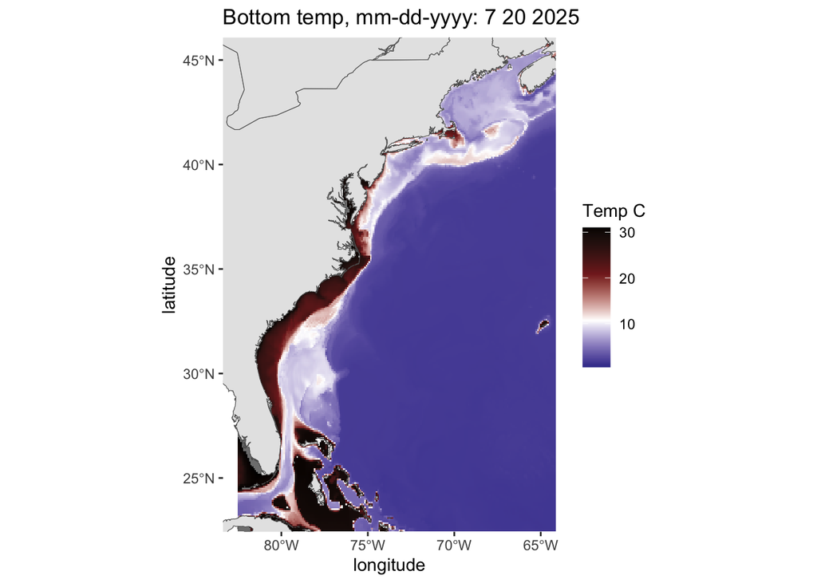

```r
ncfile <- here::here("GLORYS/testNE/2025/GLORYS_REANALYSIS_2025-07-20.nc")

# find the unit from https://ropensci.org/blog/2019/11/05/tidync/
tunit <- ncmeta::nc_atts(ncfile, "time") %>% tidyr::unnest(cols = c(value)) %>% dplyr::filter(name == "units")
# its hours since 1950-01-01

glorysnctotibble <- function(ncfile = ncfile){
  # time is hours since 1950-01-01
  origin <- as.Date("1950-01-01")

  # add the time variable into each
  time <- tidync::tidync(ncfile) |>
    tidync::activate("D0") |> tidync::hyper_array()

 # google says 86400000 milliseconds in a day
  # irrelevant because this unit is hours in a day

  bttib <- tidync::tidync(ncfile) |>
    tidync::hyper_tibble(force = TRUE) |>
    dplyr::mutate(time = unname(time$time)) |>
    dplyr::mutate(date = as.Date((time/24), origin = origin),
                  year = lubridate::year(date),
                  month = lubridate::month(date),
                  day = lubridate::day(date))|>
    dplyr::mutate(longitude = as.numeric(longitude),
                  latitude = as.numeric(latitude)) |>
    dplyr::rename(mod_bt = bottomT)

  return(bttib)
}

dailybtplot <- function(oneday, xlim = c(-82.5, -65), ylim = c(23.5, 45)){
  ggplot() +
    geom_tile(data = oneday, aes(x = longitude, y = latitude, fill = mod_bt)) +
    geom_sf(data = ecodata::coast) +
    #geom_point(data = FishStatsUtils::northwest_atlantic_grid, aes(x = Lon, y = Lat), size=0.05, alpha=0.1) +
    scale_fill_gradientn(name = "Temp C",
                         limits = c(0.5, 31),
                         colours = c(scales::muted("blue"), "white",
                                     scales::muted("red"), "black")) +
    #coord_sf(xlim = c(-77, -65), ylim = c(35, 45)) +
    #oord_sf(xlim = c(-82.5, -71), ylim = c(23.5, 36)) +
    coord_sf(xlim = xlim, ylim = ylim) +
    ecodata::theme_map() +
    ggtitle(paste("Bottom temp, mm-dd-yyyy:", unique(oneday$month),
                   unique(oneday$day), unique(oneday$year), sep = " "))
}

jul2025 <- glorysnctotibble(ncfile)

dailybtplot(jul2025)
```

Zoom in on the SADL area

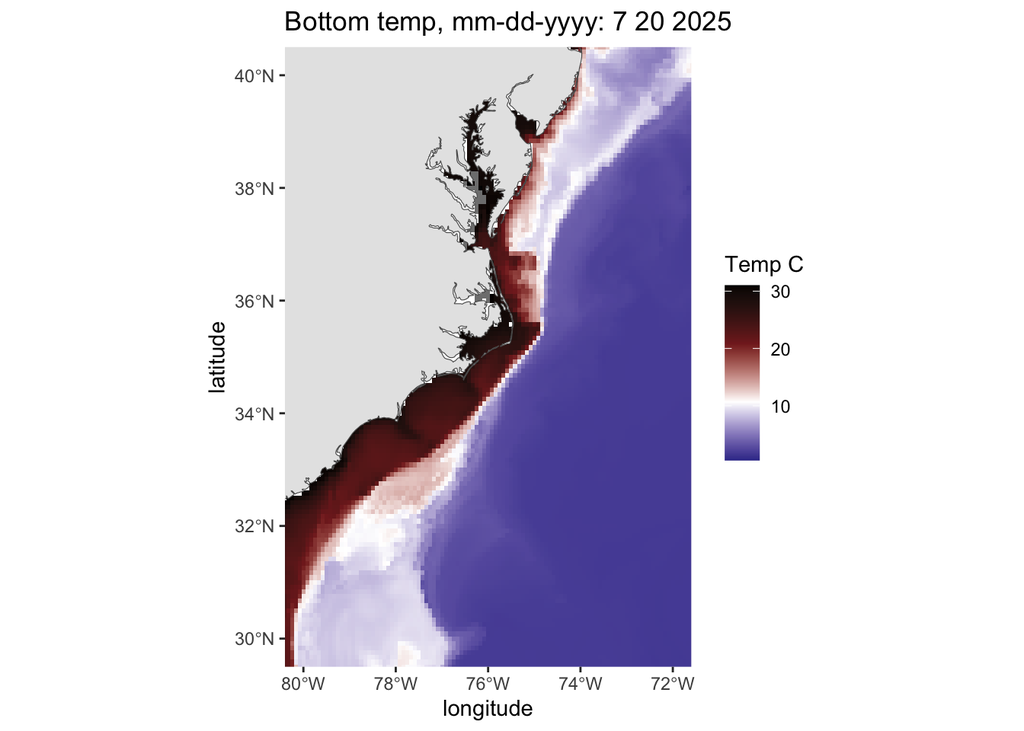

```r
dailybtplot(jul2025,
            xlim = c(-80, -72),
            ylim = c(30, 40))
```

What does September 20 look like?

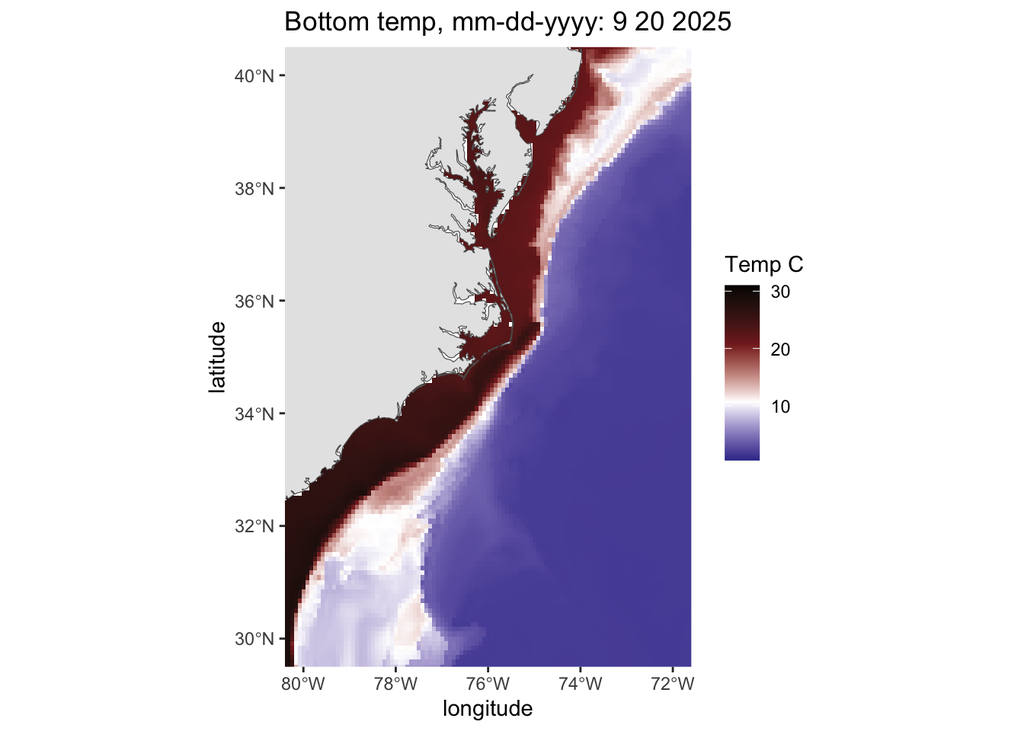

```r
ncfile <- here::here("GLORYS/testNE/2025/GLORYS_REANALYSIS_2025-09-20.nc")

sep2025 <- glorysnctotibble(ncfile)

dailybtplot(sep2025,
            xlim = c(-80, -72),
            ylim = c(30, 40))
```

Really zoom in off Hatteras and VA

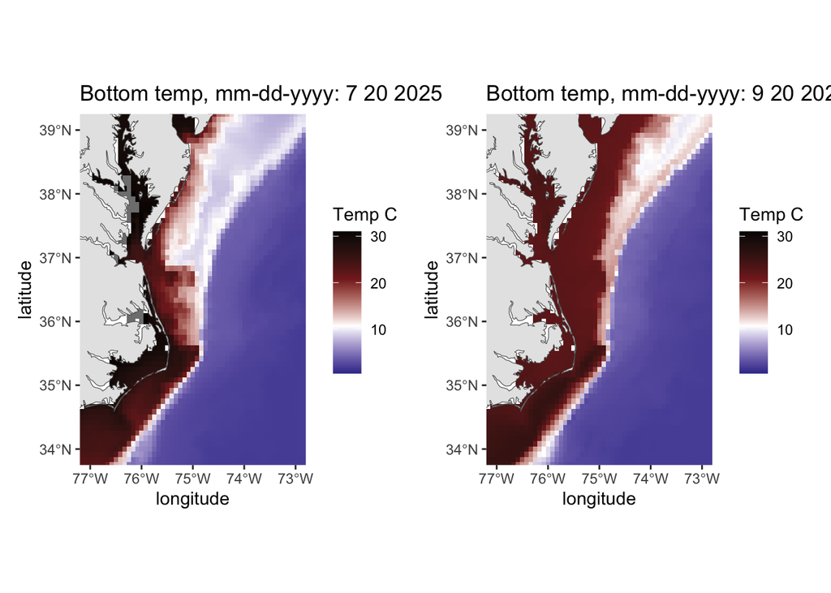

```r
j <- dailybtplot(jul2025,
            xlim = c(-77, -73),
            ylim = c(34, 39))

s <- dailybtplot(sep2025,
            xlim = c(-77, -73),
            ylim = c(34, 39))


j + s
```

Even more zoom

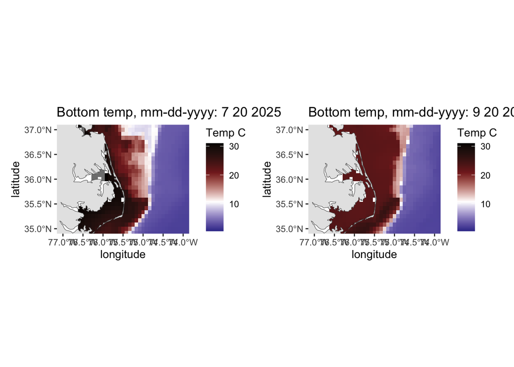

```r
j <- dailybtplot(jul2025,
            xlim = c(-77, -74),
            ylim = c(35, 37))

s <- dailybtplot(sep2025,
            xlim = c(-77, -74),
            ylim = c(35, 37))


j + s
```

One degree each dimension, now you can see the 1/12 degree resolution of the bottom temperature information.

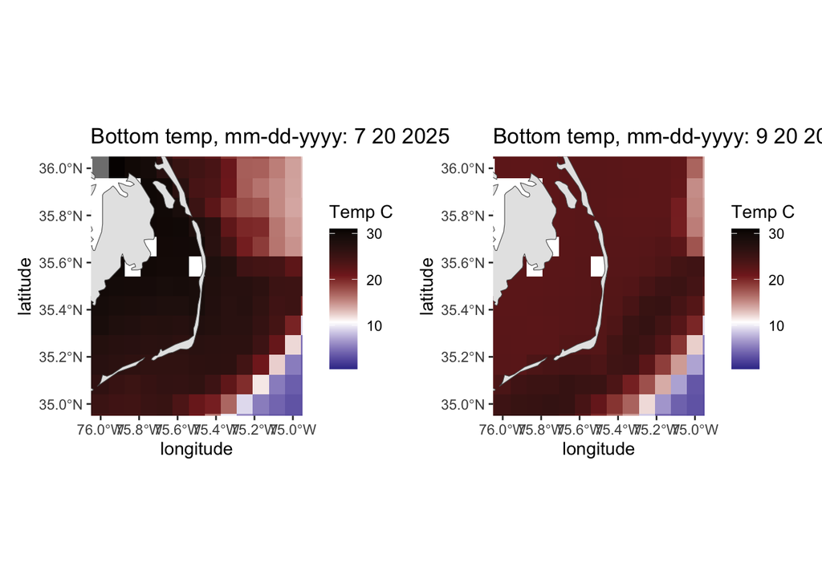

```r
j <- dailybtplot(jul2025,
            xlim = c(-76, -75),
            ylim = c(35, 36))

s <- dailybtplot(sep2025,
            xlim = c(-76, -75),
            ylim = c(35, 36))


j + s
```

This information is available daily for the period of the SADL survey 2023-2025.

## 3 How well does it match in situ measurements?

This has not been done for this region or time specifically.

Ideally there would be measurements of temperature from the SADL survey.

GLORYS bottom temperature was compared with NEFSC Bottom Trawl Survey temperatures for spring and fall surveys here: https://noaa-edab.github.io/benthosindex/BottomTempFill.html

In general, GLORYS and survey measured bottom temperatures compared favorably in this region. However, the area around Cape Hatteras did tend to have mismatches more than other areas, perhaps due to the resolution of GLORYS being unable to capture changes in temperature over relatively small distances in this region.

The NEFSC Bottom Trawl Survey does not operate at the same time as the SADL survey so these comparisons may not be representative of how well or poorly GLORYS bottom temperature might match in situ temperature in the SADL region July-October.

## References

1.

Jean-Michel L, Eric G, Romain B-B, Gilles G, Angélique M, Marie D, et al. The Copernicus Global 1/12° Oceanic and Sea Ice GLORYS12 Reanalysis. Frontiers in Earth Science. 2021;9. doi:10.3389/feart.2021.698876